# GWAS Case Study with Continuous Trait

Here we introduce a hands-on practice of a case study on genome-wide association study with **continuous traits**. This breast cancer study of Polish Caucasion cohort aims to identify new CYP2D6 DNA variants associated with impaired metabolism of tamoxifen toward endoxifen, and can be used to predicting efficacy of tamoxifen treatment. In this notebook, we will use their preprocessed **192 DNA samples** selected from the Polish Caucasian cohort to show you a typical GWAS workflow. The selection of these 192 samples is based on ratio of the sum of two tamoxifen active metabolite ((Z)-endoxifen and (Z)-4-OH-Tam) plasma concentrations to the sum of the concentrations of tamoxifen and the remaining measured compounds. As a result, 96 samples were from patients with the highest ratio, and 96 were from those with the lowest ratio. Please refer to the following paper if you are interested in details of this data.

**Reference paper:** Hennig EE, Piatkowska M, Goryca K, Pospiech E, Paziewska A, Karczmarski J, Kluska A, Brewczynska E, Ostrowski J "[Non-CYP2D6 variants selected by GWAS improved the prediction of impaired tamoxifen metabolism in breast cancer patients](https://www.ncbi.nlm.nih.gov/pmc/articles/PMC6722498/)." J Clin Med. 2019 Aug; 8(8): 1087. doi: 10.3390/jcm8081087

**Important: Raw Whole Genome Sequencing data can be very large, more than 1Gb. We will show you the codes about how to download and preprocess the raw genotype data from start. But to run the analysis on laptop with limited memory, we will subset the genotype data to only the first 1000 SNPs.**

**Special notes for Windows users: Windows has two command-line shells, Command shell and Windows Powershell. Command shell is specific to Windows system and can be run from RStudio Terminal or in "Command Prompt" App, but the lanugage it uses is NOT the same as Bash! Powershell App is the only place to run Bash commands in Windows. Therefore if you are Windows users and use RStudio for this course, you can't run bash codes such as "head" or "awk" from RStudio Terminal, you can **ONLY** run PLINK program codes. If you would like to try Bash codes, please open "Windows Powershell" app and follow the same steps to set the paths. Still, Powershell App won't run PLINK codes, so you'll have to switch between Pwershell and RStudio Terminal.**

# Environment setting and packages

Before we can run any analysis, we need to set the working path in both R and bash and install the necessary R packages. To setup the working directory, make sure you run the following codes in R.

```python
# change the path below to where you saved "bigcare-main" folder
## run in R Terminal
mydir="/path/to/bigcare-main/Data/case_data"
cd $mydir
```

[output not shown]

```python
# R codes- run in R Console
setwd("/path/to/bigcare-main/Data/case_data")
```

[output not shown]

The packages we will use in this notebook include: data.table, GEOquery (from Biocondector), GenABEL, qqman, png and QCGWAS. You will need to install these packages by yourself in R. The codes to install these packages are list below and are commented out with `#`.

```python
# R codes- run in R Console
#install.packages("data.table")
#install.packages("qqman")
#install.packages("png")
#install.packages("QCGWAS")

#if (!require("BiocManager", quietly = TRUE))
#    install.packages("BiocManager")

#BiocManager::install("GEOquery")
```

After installation, the list of packages are loaded with `library()` function.

**The following code might generate multiple message when loading the packages,such as "The following objects are masked from XXX", which is normal. You can ignore them.**

```python
# R codes- run in R Console
#load R packages
library(data.table)
library(GEOquery)
library(qqman)
library(png)
library(QCGWAS)
```

# Accessing data

## Data availability

**Important: Geonotype data is too large to be uploaded to Github so you can't run codes in this section directly without the data. You can follow the codes below to try download them on your own computer if you have enough storage. We will just load from our downloaded data here.**

The data for the study **GSE129162** can be downloaded from NCBI data warehouse website. The link is https://www.ncbi.nlm.nih.gov/geo/query/acc.cgi?acc=GSE129162

The following code can download the pheonotype and genotype data.

**Phenotype data:**  
**GSE129162_series_matrix.txt.gz** can be downloaded using [this link](https://ftp.ncbi.nlm.nih.gov/geo/series/GSE129nnn/GSE129162/matrix/). You can also download by running the following bash code if you have the exact url of the download files.`wget` command is followed by the files address, meaning that we want to download the data located in this address. Then we will unzip the file using `gunzip` command.

```python
# bash codes- run in terminal
# Windows user need to run in Powershell App
# data_path=/path/to/bigcare-main/Data/case_data
# wget ftp://ftp.ncbi.nlm.nih.gov/geo/series/GSE129nnn/GSE129162/matrix/GSE129162_series_matrix.txt.gz -P $data_path
# gunzip $data_path/*gz #this code replaces the .gz file with an uncompressed file
```

The platform data **GPL16104-1240.txt** is used for genotype annotation and can be downloaded from link https://www.ncbi.nlm.nih.gov/geo/query/acc.cgi?acc=GPL16104.

**Genotype data:**  
**GSE129162_Plate_1_Full_Data_Table.txt.gz**(96 samples) is downloaded from [this link](https://ftp.ncbi.nlm.nih.gov/geo/series/GSE129nnn/GSE129162/suppl/GSE129162%5FPlate%5F1%5FFull%5FData%5FTable%2Etxt%2Egz)  
**GSE129162_Plate_2_Full_Data_Table.txt.gz**(96 samples) is downloaded from [this link](https://ftp.ncbi.nlm.nih.gov/geo/series/GSE129nnn/GSE129162/suppl/GSE129162%5FPlate%5F2%5FFull%5FData%5FTable%2Etxt%2Egz)

**These files are extremely large and will take long time to finish.**

The following code is what we used to download and unzip the genotype data. You can try practice `wget` command using some small data on your own computer.

```python
# bash codes- run in terminal
# Windows user need to run in Powershell App
# data_path=/path/to/bigcare-main/Data/case_data
# wget https://ftp.ncbi.nlm.nih.gov/geo/series/GSE129nnn/GSE129162/suppl/GSE129162%5FPlate%5F1%5FFull%5FData%5FTable%2Etxt%2Egz -P $data_path
# wget https://ftp.ncbi.nlm.nih.gov/geo/series/GSE129nnn/GSE129162/suppl/GSE129162%5FPlate%5F2%5FFull%5FData%5FTable%2Etxt%2Egz -P $data_path
# gunzip $data_path/*gz
```

## Data files documentation

Below is a brief summary of the data information we need and their location in file. You can view the phenotype data by directly opening the file in `data` folder. But the platform and genotype data is too large to load here (genotype data is 8.2GB each, and platform data is 85.2MB). They are saved at our central folder to save space, and we will read these data from there when we start analysis.

You can open the phenotype data to check the file format directly, but the genotype data will be too large to upload to Github. You can download to your laptop if there's enough storage.

We have subsetted only 1000 SNPs from the raw genotype data. The subsetted data are saved as `GSE129162_1k_geno1.txt` and `GSE129162_1k_geno2.txt`. We will directly use these subsetted data for following analysis.

Let's first use `head` to print only the first several lines of the data and show you the file format.

```python
# bash codes- run in terminal
# Windows user need to run in Powershell App
#platform
head GPL16104-1240.txt
```

```
#ID =
#Chr = Chromosome on which the probe is located
#Position = Position of the probe on chromosome
#SNP_ID = NCBI SNP accession
#SPOT_ID =
ID	Chr	Position	SNP_ID	SPOT_ID
rs2698846	0	0	rs2698846
rs2542903	0	0	rs2542903
rs1059667	0	0	rs1059667
rs35144699	0	0	rs35144699
```

```python
# bash codes- run in terminal
# Windows user need to run in Powershell App
# genotype
head -n 2 GSE129162_1k_geno1.txt
```

```
Index	Name	Address	Chr	Position	GenTrain Score	Frac A	Frac C	Frac G	Frac T	3TX.GType	3TX.Score	3TX.Theta	3TX.R	23TX.GType	23TX.Score	23TX.Theta	23TX.R	41TX.GType	41TX.Score	41TX.Theta	41TX.R	54TX.GType	54TX.Score	54TX.Theta	54TX.R	76TX.GType	76TX.Score	76TX.Theta	76TX.R	94TX.GType	94TX.Score	94TX.Th…
1	rs2661837	59608986	6	160790174	0.9184957	0.2704918	0.204918	0.147541	0.3770492	AA	0.5307649	0.008821869	0.8875614	AA	0.5307649	0.004302552	0.789067	AA	0.5307649	0.0009787768	0.8586947	AA	0.5307649	0	0.8736661	AA	0.5307649	0	0.8482536	AA	0.5307649	0.0005487994	0.8785542	AA	0.5307649	0.005057058	0.8…
```

```python
# bash codes- run in terminal
# Windows user need to run in Powershell App
head sampleID.txt
```

```
id
3TX
23TX
41TX
54TX
76TX
94TX
109TX
130TX
5TX
```

## Extract phenotype data

There are 14 metabolites phenotype data, but we won't analyze all of them. Also, as there are many useless information in the original phenotype file, we need to extract only the information we use for analysis.

We will use the `getGEO` function from `GEOquery` package to read in this data. `GEOquery`is a very useful tool to handle GEO accession data like this. A detailed documentation of `GEOquery` package can be found [here](https://www.bioconductor.org/packages/release/bioc/manuals/GEOquery/man/GEOquery.pdf). `getGPL=FALSE` arguement means that we won't include the GPL information in this matrix.

You might see a message of "Use `spec()` for the full column specification" message when running the code below. This is a normal message from the function telling you that it parsed the characteristic information for you. Please don't worry about this.

```python
# R codes- run in R Console
my_gse <-"GSE129162"
my_pheno <- getGEO(GEO=my_gse, filename="GSE129162_series_matrix.txt", getGPL=FALSE)
```

`ls` lists the current objects we have loaded, and we will see `my_pheno` is already there.

```python
# R codes- run in R Console
ls()
```

1. 'my_gse'

2. 'my_pheno'

The codes below show that `my_pheno` is an **ExpressionSet** object which can be manipulated easily in R. We also print a brief summary of `my_pheno`, which shows that we have 192 samples.

```python
# R codes- run in R Console
class(my_pheno)
show(my_pheno)
```

'ExpressionSet'

```
ExpressionSet (storageMode: lockedEnvironment)
assayData: 0 features, 192 samples
  element names: exprs
protocolData: none
phenoData
  sampleNames: GSM3701423 GSM3701424 ... GSM3701614 (192 total)
  varLabels: title geo_accession ... z-endoxifen ratio:ch1 (62 total)
  varMetadata: labelDescription
featureData: none
experimentData: use 'experimentData(object)'
  pubMedIds: 31344832
Annotation: GPL16104
```

Data stored in `my_pheno` can be extracted using `pData`. Here we will print the first 6 rows to take a look.

```python
# R codes- run in R Console
head(pData(my_pheno))
```

A data.frame: 6 × 62

|  | title <chr> | geo_accession <chr> | status <chr> | submission_date <chr> | last_update_date <chr> | type <chr> | channel_count <chr> | source_name_ch1 <chr> | organism_ch1 <chr> | characteristics_ch1 <chr> | ⋯ | 4-oh-tam-o-gluc:ch1 <chr> | 4prim-oh-ndm-tam:ch1 <chr> | 4prim-oh-tam:ch1 <chr> | ndm-tam:ch1 <chr> | patient diagnosis:ch1 <chr> | tam-n-gluc:ch1 <chr> | tam-n-oxide:ch1 <chr> | tamoxifen:ch1 <chr> | tissue:ch1 <chr> | z-endoxifen ratio:ch1 <chr> |
| --- | --- | --- | --- | --- | --- | --- | --- | --- | --- | --- | --- | --- | --- | --- | --- | --- | --- | --- | --- | --- | --- |
| GSM3701423 | 3TX | GSM3701423 | Public on Sep 18 2019 | Apr 01 2019 | Sep 18 2019 | genomic | 1 | blood | Homo sapiens | tissue: blood | ⋯ | 0.093 | 3.724 | 3.67 | 158.63 | breast cancer | 0.09 | 9.51 | 136.63 | blood | 0.024134673 |
| GSM3701424 | 23TX | GSM3701424 | Public on Sep 18 2019 | Apr 01 2019 | Sep 18 2019 | genomic | 1 | blood | Homo sapiens | tissue: blood | ⋯ | 0.132 | 2.67 | 2.39 | 174.85 | breast cancer | 0.34 | 7.3 | 110.38 | blood | 0.014308285 |
| GSM3701425 | 41TX | GSM3701425 | Public on Sep 18 2019 | Apr 01 2019 | Sep 18 2019 | genomic | 1 | blood | Homo sapiens | tissue: blood | ⋯ | 0.147 | 3.665 | 3.89 | 195.63 | breast cancer | 0.1 | 9.79 | 145.73 | blood | 0.011294447 |
| GSM3701426 | 54TX | GSM3701426 | Public on Sep 18 2019 | Apr 01 2019 | Sep 18 2019 | genomic | 1 | blood | Homo sapiens | tissue: blood | ⋯ | 0.08 | 6.624 | 4.1 | 280.15 | breast cancer | 0.21 | 21.05 | 169.76 | blood | 0.006079783 |
| GSM3701427 | 76TX | GSM3701427 | Public on Sep 18 2019 | Apr 01 2019 | Sep 18 2019 | genomic | 1 | blood | Homo sapiens | tissue: blood | ⋯ | 0.462 | 6.374 | 4.18 | 300.06 | breast cancer | 0.47 | 27.72 | 194.25 | blood | 0.00701069 |
| GSM3701428 | 94TX | GSM3701428 | Public on Sep 18 2019 | Apr 01 2019 | Sep 18 2019 | genomic | 1 | blood | Homo sapiens | tissue: blood | ⋯ | 0.027 | 6.182 | 3.51 | 303.72 | breast cancer | 0.31 | 28.71 | 167.92 | blood | 0.002365497 |

As you can see, the table size is too large and contain too many useless information. `colnames` function can help us to check what information is contained in this data table by printing all the column names.

```python
# R codes- run in R Console
colnames(pData(my_pheno))
```

1. 'title'

2. 'geo_accession'

3. 'status'

4. 'submission_date'

5. 'last_update_date'

6. 'type'

7. 'channel_count'

8. 'source_name_ch1'

9. 'organism_ch1'

10. 'characteristics_ch1'

11. 'characteristics_ch1.1'

12. 'characteristics_ch1.2'

13. 'characteristics_ch1.3'

14. 'characteristics_ch1.4'

15. 'characteristics_ch1.5'

16. 'characteristics_ch1.6'

17. 'characteristics_ch1.7'

18. 'characteristics_ch1.8'

19. 'characteristics_ch1.9'

20. 'characteristics_ch1.10'

21. 'characteristics_ch1.11'

22. 'characteristics_ch1.12'

23. 'characteristics_ch1.13'

24. 'characteristics_ch1.14'

25. 'characteristics_ch1.15'

26. 'molecule_ch1'

27. 'extract_protocol_ch1'

28. 'label_ch1'

29. 'label_protocol_ch1'

30. 'taxid_ch1'

31. 'hyb_protocol'

32. 'scan_protocol'

33. 'description'

34. 'description.1'

35. 'data_processing'

36. 'data_processing.1'

37. 'platform_id'

38. 'contact_name'

39. 'contact_department'

40. 'contact_institute'

41. 'contact_address'

42. 'contact_city'

43. 'contact_zip/postal_code'

44. 'contact_country'

45. 'supplementary_file'

46. 'data_row_count'

47. '(e)-a-oh-tam:ch1'

48. '(e)-endoxifen:ch1'

49. '(z)-4-oh-tam + 3-oh-tam:ch1'

50. '(z)-a-oh-tam:ch1'

51. '(z)-endoxifen + 3-oh-ndm-tam:ch1'

52. '4-oh-ndm-tam-gluc:ch1'

53. '4-oh-tam-o-gluc:ch1'

54. '4prim-oh-ndm-tam:ch1'

55. '4prim-oh-tam:ch1'

56. 'ndm-tam:ch1'

57. 'patient diagnosis:ch1'

58. 'tam-n-gluc:ch1'

59. 'tam-n-oxide:ch1'

60. 'tamoxifen:ch1'

61. 'tissue:ch1'

62. 'z-endoxifen ratio:ch1'

Here, we will only extract the sample ID and all 14 metabolites data from the large table. `pheno_var` lists all the column names of the data we will extract, and these extracted data will be saved in object `phenotype`. We will still print the first 6 rows as a preview. You can see that the table becomes much smaller and only contains the data we will use.

```python
# R codes- run in R Console
pheno_var<- c('title','(e)-a-oh-tam:ch1','(e)-endoxifen:ch1',
              '(z)-4-oh-tam + 3-oh-tam:ch1','(z)-a-oh-tam:ch1',
              '(z)-endoxifen + 3-oh-ndm-tam:ch1','4-oh-ndm-tam-gluc:ch1',
              '4-oh-tam-o-gluc:ch1','4prim-oh-ndm-tam:ch1','4prim-oh-tam:ch1',
              'ndm-tam:ch1','tam-n-gluc:ch1','tam-n-oxide:ch1','tamoxifen:ch1',
              'z-endoxifen ratio:ch1')
phenotype <- pData(my_pheno)[,pheno_var]
head(phenotype)
```

A data.frame: 6 × 15

|  | title <chr> | (e)-a-oh-tam:ch1 <chr> | (e)-endoxifen:ch1 <chr> | (z)-4-oh-tam + 3-oh-tam:ch1 <chr> | (z)-a-oh-tam:ch1 <chr> | (z)-endoxifen + 3-oh-ndm-tam:ch1 <chr> | 4-oh-ndm-tam-gluc:ch1 <chr> | 4-oh-tam-o-gluc:ch1 <chr> | 4prim-oh-ndm-tam:ch1 <chr> | 4prim-oh-tam:ch1 <chr> | ndm-tam:ch1 <chr> | tam-n-gluc:ch1 <chr> | tam-n-oxide:ch1 <chr> | tamoxifen:ch1 <chr> | z-endoxifen ratio:ch1 <chr> |
| --- | --- | --- | --- | --- | --- | --- | --- | --- | --- | --- | --- | --- | --- | --- | --- |
| GSM3701423 | 3TX | 0.39 | 0 | 2.1 | 0 | 7.62 | 0.773 | 0.093 | 3.724 | 3.67 | 158.63 | 0.09 | 9.51 | 136.63 | 0.024134673 |
| GSM3701424 | 23TX | 0.546 | 0 | 1.77 | 0.041 | 4.31 | 0.888 | 0.132 | 2.67 | 2.39 | 174.85 | 0.34 | 7.3 | 110.38 | 0.014308285 |
| GSM3701425 | 41TX | 0.531 | 0 | 1.46 | 0 | 4.09 | 0.725 | 0.147 | 3.665 | 3.89 | 195.63 | 0.1 | 9.79 | 145.73 | 0.011294447 |
| GSM3701426 | 54TX | 0.496 | 0 | 2.19 | 0.063 | 2.95 | 0.329 | 0.08 | 6.624 | 4.1 | 280.15 | 0.21 | 21.05 | 169.76 | 0.006079783 |
| GSM3701427 | 76TX | 0.339 | 0 | 1.67 | 0.079 | 3.77 | 1.719 | 0.462 | 6.374 | 4.18 | 300.06 | 0.47 | 27.72 | 194.25 | 0.00701069 |
| GSM3701428 | 94TX | 0.303 | 0 | 1.1 | 0.064 | 1.21 | 0.104 | 0.027 | 6.182 | 3.51 | 303.72 | 0.31 | 28.71 | 167.92 | 0.002365497 |

You can also explore other columns using `$` and `head`. You can play with this code by changing it to different columns.

```python
# R codes- run in R Console
# explore each one
head(pData(my_pheno)$characteristics_ch1.3)
```

1. '(z)-endoxifen + 3-oh-ndm-tam: 7.62'

2. '(z)-endoxifen + 3-oh-ndm-tam: 4.31'

3. '(z)-endoxifen + 3-oh-ndm-tam: 4.09'

4. '(z)-endoxifen + 3-oh-ndm-tam: 2.95'

5. '(z)-endoxifen + 3-oh-ndm-tam: 3.77'

6. '(z)-endoxifen + 3-oh-ndm-tam: 1.21'

We also need to check the variables class to make sure they are read in correctly.

```python
# R codes- run in R Console
apply(phenotype,2,class)
```

**title**

'character'

**(e)-a-oh-tam:ch1**

'character'

**(e)-endoxifen:ch1**

'character'

**(z)-4-oh-tam + 3-oh-tam:ch1**

'character'

**(z)-a-oh-tam:ch1**

'character'

**(z)-endoxifen + 3-oh-ndm-tam:ch1**

'character'

**4-oh-ndm-tam-gluc:ch1**

'character'

**4-oh-tam-o-gluc:ch1**

'character'

**4prim-oh-ndm-tam:ch1**

'character'

**4prim-oh-tam:ch1**

'character'

**ndm-tam:ch1**

'character'

**tam-n-gluc:ch1**

'character'

**tam-n-oxide:ch1**

'character'

**tamoxifen:ch1**

'character'

**z-endoxifen ratio:ch1**

'character'

From the table of `phenotype` above, we can see that the class of characters are not recognized correctly. All the metabolites data are recognized as `character` while they should be `numeric`. Therefore, we need to change the types of these varaibles into the correct class before we can do further exploration.

**The codes below will generate a list of warning message saying that “NAs introduced by coercion”. This is because our phenotype data contains missing values. You don't have to worry of this as we will impute this missings in next section.**

```python
# R codes- run in R Console
#change to numeric, warning because of NA
phenotype <- cbind(phenotype[,1], apply(phenotype[,2:15],2,as.numeric))
# rename, as column names don't allow special character and numer as start
colnames(phenotype) <- c('sample_ID','(e)-a-oh-tam:ch1','(e)-endoxifen:ch1','z.4.oh.tam_3.oh.tam','z.a.oh.tam','z.endoxifen_3.oh.ndm.tam','4.oh.ndm.tam.gluc','V4.oh.tam.o.gluc','V4prim.oh.ndm.tam','V4prim.oh.tam','ndm.tam','tam.n.gluc','tam.n.oxide','tamoxifen','z.endoxifen_ratio')
#save
write.table(phenotype,"phenotype.txt",
            sep="\t", quote=F, row.name=F,col.names=T)
```

[output not shown]

# Summary of Phenotypes Data

- Phenotype data:
  - **phenotype.txt** #Col 1 is sample ID, Col 2-15 are metabolites data.

As we said in the last step, there are missing values in the phenotype data. We also need to check the distribution of this phenotype data to see if other preprossessing steps such as normalization is needed.

The following code load the **phenotype** data with `fread`. We can see that the variables are read in with correct class.

```python
# R codes- run in R Console
# Read data
phenotype=fread("phenotype.txt", header=T)
head(phenotype)
```

A data.table: 6 × 15

| sample_ID <chr> | (e)-a-oh-tam:ch1 <dbl> | (e)-endoxifen:ch1 <dbl> | z.4.oh.tam_3.oh.tam <dbl> | z.a.oh.tam <dbl> | z.endoxifen_3.oh.ndm.tam <dbl> | 4.oh.ndm.tam.gluc <dbl> | V4.oh.tam.o.gluc <dbl> | V4prim.oh.ndm.tam <dbl> | V4prim.oh.tam <dbl> | ndm.tam <dbl> | tam.n.gluc <dbl> | tam.n.oxide <dbl> | tamoxifen <dbl> | z.endoxifen_ratio <dbl> |
| --- | --- | --- | --- | --- | --- | --- | --- | --- | --- | --- | --- | --- | --- | --- |
| 3TX | 0.390 | 0 | 2.10 | 0.000 | 7.62 | 0.773 | 0.093 | 3.724 | 3.67 | 158.63 | 0.09 | 9.51 | 136.63 | 0.024134673 |
| 23TX | 0.546 | 0 | 1.77 | 0.041 | 4.31 | 0.888 | 0.132 | 2.670 | 2.39 | 174.85 | 0.34 | 7.30 | 110.38 | 0.014308285 |
| 41TX | 0.531 | 0 | 1.46 | 0.000 | 4.09 | 0.725 | 0.147 | 3.665 | 3.89 | 195.63 | 0.10 | 9.79 | 145.73 | 0.011294447 |
| 54TX | 0.496 | 0 | 2.19 | 0.063 | 2.95 | 0.329 | 0.080 | 6.624 | 4.10 | 280.15 | 0.21 | 21.05 | 169.76 | 0.006079783 |
| 76TX | 0.339 | 0 | 1.67 | 0.079 | 3.77 | 1.719 | 0.462 | 6.374 | 4.18 | 300.06 | 0.47 | 27.72 | 194.25 | 0.007010690 |
| 94TX | 0.303 | 0 | 1.10 | 0.064 | 1.21 | 0.104 | 0.027 | 6.182 | 3.51 | 303.72 | 0.31 | 28.71 | 167.92 | 0.002365497 |

The codes below first select these specific variables from phenotype data, and save them as a new object `pheno_mr`, then rename them with even shorter abbreviations for easy handling. This `pheno_mr` is saved as **pheno_mr.txt**, and the first column of sample ID is saved as **sampleID.txt**.

```python
# R codes- run in R Console
#only select necessary pheno
pheno_mr <- phenotype[,c('sample_ID','z.4.oh.tam_3.oh.tam','tamoxifen','z.endoxifen_ratio')]
names(pheno_mr) <- c("id","z4", "tam","mr")
head(pheno_mr)
```

A data.table: 6 × 4

| id <chr> | z4 <dbl> | tam <dbl> | mr <dbl> |
| --- | --- | --- | --- |
| 3TX | 2.10 | 136.63 | 0.024134673 |
| 23TX | 1.77 | 110.38 | 0.014308285 |
| 41TX | 1.46 | 145.73 | 0.011294447 |
| 54TX | 2.19 | 169.76 | 0.006079783 |
| 76TX | 1.67 | 194.25 | 0.007010690 |
| 94TX | 1.10 | 167.92 | 0.002365497 |

```python
# R codes- run in R Console
fwrite(pheno_mr, "pheno_mr.txt", sep="\t",quote=F,row.name=F, col.name=T,na="NA")
fwrite(pheno_mr[,"id"],"sampleID.txt",sep="\t",quote=F,row.name=F, col.name=T,na="NA")
```

## Histogram of each trait

In this section, we will discover the distribution of these 3 traits using histogram. As there are missing values in the data, written as 'NA', we need to exclude them with `!is.na` when genrating the histogram. The plots are generated for each of the 3 variables with `hist` function, `xlab` argument specifies the x-axis label and `main` specifies the plot title.

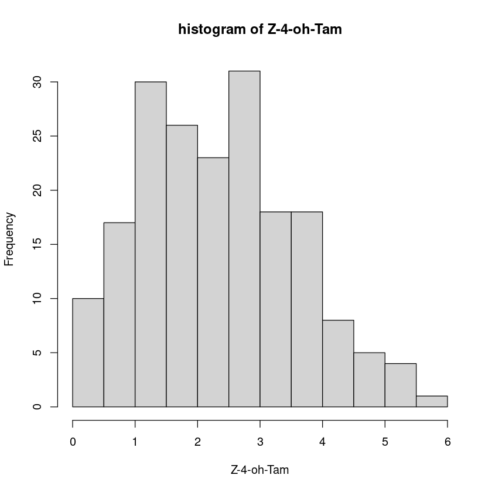

```python
# R codes- run in R Console
hist(pheno_mr$z4[!is.na(pheno_mr$z4)],xlab="Z-4-oh-Tam",main="histogram of Z-4-oh-Tam")
```

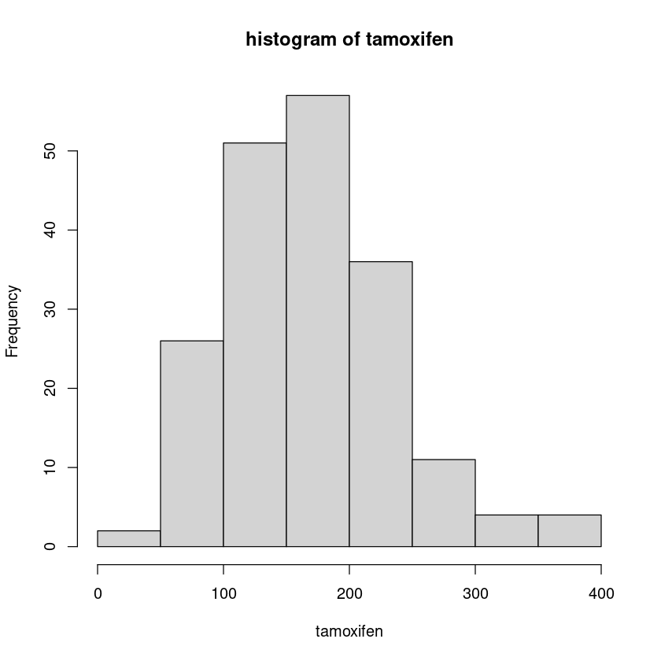

```python
# R codes- run in R Console
hist(pheno_mr$tam[!is.na(pheno_mr$tam)],xlab="tamoxifen",main="histogram of tamoxifen")
```

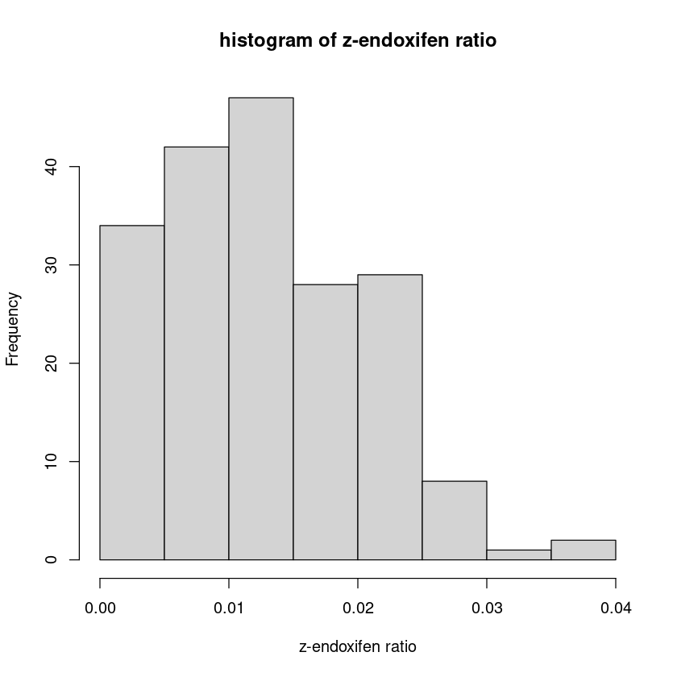

```python
# R codes- run in R Console
hist(pheno_mr$mr[!is.na(pheno_mr$mr)],xlab="z-endoxifen ratio",main="histogram of z-endoxifen ratio")
```

From the above histograms, we can see that the distribution of these 3 traits are all above zero and slightly skewed. This could violate the normality assumption as current phenotype values are all positive. We might want to perform nomalization before analysis.

## Handling the missing values in the phenotypes and covariates

Remember that we still have missing values in our phenotype data, we need to impute these NAs as well. The following code imputes the missing values in the phenotype with the mean of the variable.

In the following codes, we first exclude the first variable, "sample ID", from `pheno_mr` and save only the phenotypes as `pheno0`. Then we write a `for loop` that replaces missing values(NA) in each trait with mean of non-missing values. The imputed phenotype data is saved as `phenotype0.txt`.

```python
# R codes- run in R Console
pheno_mr <- read.table("pheno_mr.txt",header=T)
pheno0=pheno_mr[,-1] #remove sample ID (Col 1)
n=dim(pheno0)[1] #sample size
p=dim(pheno0)[2] #number of traits
for (i in 1:p){
  pheno0[is.na(pheno0[,i]),i]=mean(pheno0[!is.na(pheno0[,i]),i]) #for each trait, replace missing values with the mean of the variable
}
```

```python
# R codes- run in R Console
# view the data
head(pheno0)
```

A data.frame: 6 × 3

|  | z4 <dbl> | tam <dbl> | mr <dbl> |
| --- | --- | --- | --- |
| 1 | 2.10 | 136.63 | 0.024134673 |
| 2 | 1.77 | 110.38 | 0.014308285 |
| 3 | 1.46 | 145.73 | 0.011294447 |
| 4 | 2.19 | 169.76 | 0.006079783 |
| 5 | 1.67 | 194.25 | 0.007010690 |
| 6 | 1.10 | 167.92 | 0.002365497 |

## Checking normality assumptions for each trait

The association test is essentially a linear regression for continous reponse variable. Thus, it is worthwhile to check whether the normality assumption is valid for the responses. The **Shapiro-Wilk test** is one of the popular normality test. The following code conduct the Shapiro tests on the three response variables. When the P-value of Shapiro test is greater then 0.05, it indicates the normality assumption is valid. Please note that the normality assumption is not critical for the association test. If the sample size is large enough, the association test can also be valid even the normality assumption doesn't hold.

For more information on Shapiro-Wilk test, please refer: https://en.wikipedia.org/wiki/Shapiro%E2%80%93Wilk_test.

The following codes perform Shapiro test using `shapiro.test` function in package `stats`. We still need to exclude the NA values when doing this test, otherwise the test will result in error.

```python
# R codes- run in R Console
#Violation of this assumption can severely affect the power and type I error
shapiro.test(pheno0$z4[!is.na(pheno0$z4)])
shapiro.test(pheno0$tam[!is.na(pheno0$tam)])
shapiro.test(pheno0$mr[!is.na(pheno0$mr)])
```

```
	Shapiro-Wilk normality test

data:  pheno0$z4[!is.na(pheno0$z4)]
W = 0.97522, p-value = 0.001748
```

```
	Shapiro-Wilk normality test

data:  pheno0$tam[!is.na(pheno0$tam)]
W = 0.96659, p-value = 0.0001551
```

```
	Shapiro-Wilk normality test

data:  pheno0$mr[!is.na(pheno0$mr)]
W = 0.95304, p-value = 5.707e-06
```

However, the test results of these three traits are all lower than cut-off value 0.05, which means that we fail to accept the normality assumption and a normalization of these data is necessary.

### Normalize phenotype data

Here we are going to normalize the phenotype data using log2 transformation. We used the phenotype values `+1` here to shift possible zero values to make it acceptable by log distribution.

```python
# R codes- run in R Console
# We will do a rank-based inverse normal transformation
pheno0$z4 <- log2(pheno0$z4+1)
pheno0$tam <- log2(pheno0$tam+1)
pheno0$mr <- log2(pheno0$mr+1)
write.table(pheno0, "phenotype0.txt", row.names=F, col.names=F, quote=F, sep=" ") #save new phenotype data
```

# Covariates Adjustment

This study didn't provide any public data containing covariates information, such as AGE, BMI, and all samples are female. The only information of covariates they provided in the supplementary table is **Age** with a range of 22 to 95. **In order to show you the process of covariates adjustment in real data, we are going to generate an `Age` covariate using a series of random integers within interval 22 to 95.**

We used the following codes to generate 192 random integers within (22, 95). **Rerunning this code will generate a new series of Age and might change the results in later sections.**

```python
# R codes- run in R Console
# age<- sample(22:95, size=192,replace=TRUE)
# age
# fwrite(as.matrix(age),"age.txt",quote=F, row.names=F,col.names=F)
```

Next we will load the phenotype data and covariate data. The data is coerced to class matrix for easy manipulation in R. `n` is the sample size and `p` is number of traits. So we have 192 samples and 3 traits.

```python
# R codes- run in R Console
# Read phenotype data and covariates data
pheno=fread("phenotype0.txt") #read phenotype data
covar=read.table("age.txt") #read covariates data
pheno=as.matrix(pheno) #create a matrix from the phenotype data
covar=as.matrix(covar) #create a matrix from the covariates data
n=dim(pheno)[1] #sample size
p=dim(pheno)[2] #number of traits
n
p
```

192

3

To perform covariates adjustment, the following codes fit a linear regression of phenotype and covariates. The resulted residuals from this model will be used as the new phenotype data, and is saved in `resid_phenotype0.txt`.

```python
# R codes- run in R Console
fit=list() #create an empty list
residpheno=matrix(0, n, p) #create an empty matrix
for (i in 1:p){
  fit[[i]]=lm(pheno[,i]~covar) #for each trait, fit linear regression of phenotype against covariates
  residpheno[,i]=resid(fit[[i]]) #obtain residual phenotype data
}
write.table(residpheno, "resid_phenotype0.txt", row.names=F, col.names=F, quote=F, sep=" ") #save residual phenotype data
```

# Prepare PLINK data

**Important: Geonotype data is too large to be handled on a personal laptop. So codes in this section are all commented out. Please DON'T try them unless you run using a computational server. They are memory consuming and will take long time to finish. We simply show the codes here as an example. Later, we will subset the prepared PLINK PED and MAP file to only 1000 SNPs so they can run on laptop!**

**PLINK** is an open-source whole genomic association analysis tool that can achieve multiple functions, such as calculating summary statistics, performing imputation and different types of tests. It is a command line application, so you are not able to run it by simply clicking a button. The codes in this part are all bash codes.

**PLINK** expects 2 input data files in **.ped** and **.map** format. These are genotype files that are organized in a specific format. Please refer to the PLINK website for formats of [PED](http://zzz.bwh.harvard.edu/plink/data.shtml#ped) and [MAP](http://zzz.bwh.harvard.edu/plink/data.shtml#map) files. In this section, we will show you how to prepare our phenotype and genotype data into PED and MAP format.

PLINK can be downloaded to your own computer [here](https://zzz.bwh.harvard.edu/plink/download.shtml). Please make sure you have downloaded and unzipped the installation packages in "/bigcare-main/Tools". We will directly call PLINK from this path.

## Step 1: prepare PLINK ped file

The PED file is a white-space (space or tab) delimited file: the first six columns are mandatory:

- Family ID
- Individual ID
- Paternal ID
- Maternal ID
- Sex (1=male; 2=female; other=unknown)
- Phenotype

Staring from column 7, genotypes should also be white-space delimited; they can be any character (e.g. 1,2,3,4 or A,C,G,T or anything else) except 0 which is, by default, the missing genotype character. All markers should be biallelic. All SNPs (whether haploid or not) must have two alleles specified. Either Both alleles should be missing (i.e. 0) or neither. No header row should be given. Here is an example of the final PED file format with two individuals typed for 3 SNPs (one row = one person):

```
 FAM001  1  0 0  1  2  A A  G G  A C
 FAM001  2  0 0  1  2  A A  A G  0 0
```

Below, we will generate the first 6 columns. We don't have specific Family ID, Paternal ID and Maternal ID, so we will use a sequence of number for Family ID and 0 for Paternal and Maternal ID. Phenotype is also a sequence of 0 here, as we will use our own phenotype data later. Gender is set to 2 for all samples as they are all female. Individual ID is the sample ID, so we will use the sample ID from the phenotype data.

This code extract the sample ID from file `sampleID.txt`. `NR>=2` means we start reading the file from line 2, as we have header in the first line.

```python
# bash codes- run in terminal
# Windows user need to run in Powershell App
### Individual ID: sampleID.txt (in Linux)
awk 'NR>=2 {print}' sampleID.txt > samID.txt
head samID.txt
```

```
3TX
23TX
41TX
54TX
76TX
94TX
109TX
130TX
5TX
24TX
```

The following codes generate the files for Family ID, paternal ID, maternal ID, phenotype (all set to missing) (using R)

```python
# R codes- run in R Console
samID=read.table("samID.txt")#read sample ID
samID=as.matrix(samID) #create a matrix from samID
len=length(samID) #sample size
famID=seq(1:len) #family ID is a sequence from 1 to n (sample size)
patID=rep(0, len) #paternal ID is a sequence of 0
matID=rep(0, len) #maternal ID is a sequence of 0
gender=rep(2, len) # gender data, all female
pheno=rep(0, len) #phenotype data is a sequence of 0
write.table(famID, "famID.txt", row.names=F, col.names=F, quote=F, sep=" ") #save family ID
write.table(patID, "patID.txt", row.names=F, col.names=F, quote=F, sep=" ") #save paternal ID
write.table(matID, "matID.txt", row.names=F, col.names=F, quote=F, sep=" ") #save maternal ID
write.table(gender, "gender.txt", row.names=F, col.names=F, quote=F, sep=" ") #save gender data
write.table(pheno, "pheno.txt", row.names=F, col.names=F, quote=F, sep=" ") #save phenotype data
```

From column 7 and onwards, we need to prepare the genotype data. The following code extract the genotype data from our downloaded genotype data. The orignial genotype data has too many useless information. Here are the first several columns of the genotype header:

```
    Index   Name    Address Chr Position    GenTrain Score  Frac A  Frac C  Frac G  Frac T
    3TX.GType   3TX.Score   3TX.Theta   3TX.R   23TX.GType  23TX.Score  23TX.Theta  23TX.R
    41TX.GType  41TX.Score  41TX.Theta  41TX.R
```

```python
# bash codes- run in terminal
# Windows user need to run in Powershell App
head -n 2 GSE129162_1k_geno1.txt
```

```
Index	Name	Address	Chr	Position	GenTrain Score	Frac A	Frac C	Frac G	Frac T	3TX.GType	3TX.Score	3TX.Theta	3TX.R	23TX.GType	23TX.Score	23TX.Theta	23TX.R	41TX.GType	41TX.Score	41TX.Theta	41TX.R	54TX.GType	54TX.Score	54TX.Theta	54TX.R	76TX.GType	76TX.Score	76TX.Theta	76TX.R	94TX.GType	94TX.Score	94TX.Th…
1	rs2661837	59608986	6	160790174	0.9184957	0.2704918	0.204918	0.147541	0.3770492	AA	0.5307649	0.008821869	0.8875614	AA	0.5307649	0.004302552	0.789067	AA	0.5307649	0.0009787768	0.8586947	AA	0.5307649	0	0.8736661	AA	0.5307649	0	0.8482536	AA	0.5307649	0.0005487994	0.8785542	AA	0.5307649	0.005057058	0.8…
```

The code below is a bash code. `NR>=2` means we start print the data from 2nd row. The `for loop` extracts every 4th column starting from column 11 and print to file `geno_1k_ready1.txt` and `geno_1k_ready2.txt`.

```python
### bash codes- run in terminal
# Windows user need to run in Powershell App
### Genotype only
## from Row 2, print every 4th columns starting from column 11
awk 'NR>=2 {for(i=11;i<=NF; i+=4) {printf "%s ", $i} printf "\n"}' \
GSE129162_1k_geno1.txt > geno_1k_ready1.txt
awk 'NR>=2 {for(i=11;i<=NF; i+=4) {printf "%s ", $i} printf "\n"}' \
GSE129162_1k_geno2.txt > geno_1k_ready2.txt
```

Next we need to transpose the extracted data so that every row is a sample and every column is a SNP.

We read in the genodata from last step into R using `fread` function and check its dimension using `dim`. `fread` performs much faster on large datsets than `read.table`.

```python
# R codes- run in R Console
# Transpose genotype data (using R)
genodata1=fread("geno_1k_ready1.txt",header=F) #read genotype data
genodata2= fread("geno_1k_ready2.txt",header=F)
## check dim
dim(genodata1)
dim(genodata2)
### 1000 snp and 96 sample
head(genodata1)
```

1. 1000

2. 96

1. 1000

2. 96

A data.table: 6 × 96

| V1 <chr> | V2 <chr> | V3 <chr> | V4 <chr> | V5 <chr> | V6 <chr> | V7 <chr> | V8 <chr> | V9 <chr> | V10 <chr> | ⋯ | V87 <chr> | V88 <chr> | V89 <chr> | V90 <chr> | V91 <chr> | V92 <chr> | V93 <chr> | V94 <chr> | V95 <chr> | V96 <chr> |
| --- | --- | --- | --- | --- | --- | --- | --- | --- | --- | --- | --- | --- | --- | --- | --- | --- | --- | --- | --- | --- |
| AA | AA | AA | AA | AA | AA | AA | AA | AA | AA | ⋯ | AA | AA | AA | AA | AA | AA | AA | AA | AA | NC |
| BB | BB | BB | BB | BB | BB | BB | BB | BB | BB | ⋯ | BB | AB | BB | BB | BB | BB | BB | BB | BB | AB |
| AA | AA | BB | AB | AA | BB | AB | AA | AB | BB | ⋯ | AA | AA | BB | AA | AA | AA | AA | AA | AA | AB |
| AB | AA | BB | AB | AB | BB | AA | AB | BB | BB | ⋯ | AB | BB | BB | AA | AB | AA | AB | AB | AB | AB |
| BB | BB | AB | BB | AB | AA | BB | BB | AB | AA | ⋯ | AB | BB | BB | BB | BB | AB | AB | BB | BB | BB |
| AB | BB | BB | BB | BB | BB | AB | BB | BB | BB | ⋯ | BB | BB | BB | BB | AB | NC | AB | BB | BB | BB |

There are 1,000 SNPs for each of the 96 samples in each dataset. Next, we are going to combine these 2 genotype data into one, and transpose it. **In the orignial genotype file, there are 2,567,845 SNPs which is too large to run on laptops.**

These 2 datasets need to be converted to matrix first and combined with `cbind` before transposing. The transpose is done with `t()` function in R. The complete genotype data is saved as `genodata_1k.txt` (~1MB).

```python
# R codes- run in R Console
genodata1=as.matrix(genodata1) #create a matrix from the genotype data
genodata2=as.matrix(genodata2)

genodata <- cbind(genodata1,genodata2)
##save transposed genotype data
write.table(t(genodata), "genodata_1k.txt", row.names=F, col.names=F, quote=F, sep=" ")
### Each row is a sample, each column is a SNP

dim(genodata)
```

1. 1000

2. 192

It is very important that in PED file, **all marker should be biallelic.** The genotype is orginal data is in format of AA,AB,BB. So allels need to be delimited by space and changed with `A=A`, `B=G` and `NC=0 0`. (`NC` means "no call", which indicates missing. The expression of missing may not always be `NC` so you need to check your original genotype before this step. )

Here, we will achieve this by using the bash command `sed`. We will run using the subsetted genotype data "genodata_1k.txt".

```python
# bash codes- run in terminal
# Windows user need to run in Powershell App
# Replace 'A' with 'A ', 'B' with 'G ', NC(NoCall) with '0 ' in genodata (in Linux)
sed -i -e 's/A/A /g' genodata_1k.txt
sed -i -e 's/B/G /g' genodata_1k.txt
sed -i -e 's/NC/0 0/g' genodata_1k.txt
```

```python
# bash codes- run in terminal
# Windows user need to run in Powershell App
### PED file (in Linux)
paste -d' ' \
famID.txt samID.txt patID.txt matID.txt gender.txt pheno.txt genodata_1k.txt > genotype_1k.ped
```

## Step 2: prepare PLINK map file

By default, each line of the MAP file describes a single marker and must contain exactly 4 columns:

- chromosome (1-22, X, Y or 0 if unplaced)
- rs# or snp identifier
- Genetic distance (morgans)
- Base-pair position (bp units)

These information can be extracted from the platform data `GPL16104-1240.txt`. The following codes extract the information we need in bash.

In the platform data, because SNP information starts at line 6, we use `tail -n+6` to print all data from the 6th row and save it as `datatable.txt`. Then we cut the first 4 columns from `datatable.txt`, which are `ID`, `Chr`, `Position` and `SNP_ID`, and save it as `map0.txt`.

```python
# bash codes- run in terminal
# Windows user need to run in Powershell App
head GPL16104-1240.txt
```

```
#ID =
#Chr = Chromosome on which the probe is located
#Position = Position of the probe on chromosome
#SNP_ID = NCBI SNP accession
#SPOT_ID =
ID	Chr	Position	SNP_ID	SPOT_ID
rs2698846	0	0	rs2698846
rs2542903	0	0	rs2542903
rs1059667	0	0	rs1059667
rs35144699	0	0	rs35144699
```

```python
# bash codes- run in terminal
# Windows user need to run in Powershell App
### Row 31 (in Linux)
tail -n+6 GPL16104-1240.txt > datatable.txt
```

```python
# bash codes- run in terminal
# Windows user need to run in Powershell App
### Obtain ID, SPOT_ID, chromosome, and physical position (in Linux)
cut -f1,2,3,4 datatable.txt > map0.txt
head map0.txt
```

```
ID	Chr	Position	SNP_ID
rs2698846	0	0	rs2698846
rs2542903	0	0	rs2542903
rs1059667	0	0	rs1059667
rs35144699	0	0	rs35144699
rs35425675	0	0	rs35425675
rs3876241	0	0	rs3876241
rs160179	0	0	rs160179
rs12065999	0	0	rs12065999
rs2571902	0	0	rs2571902
```

Then, the list of SNPs in orignial genotype data was extracted and matched with the SNPs in platform, because we will contain the annotation of the same list of SNPs in genotype file as in the MAP file.

```python
# bash codes- run in terminal
# Windows user need to run in Powershell App
### SNP ID in discovery set (in Linux)
awk 'NR>=2 {print $2}' GSE129162_1k_geno1.txt > SNPID.txt
### Extract map0 to be matched with SNPID (in Linux)
extractrows.pl SNPID.txt map0.txt > map1.txt
```

Next. we could construct the MAP file. The MAP file must contain as many markers as are in the PED file. The markers in the PED file do not need to be in genomic order, BUT the order of MAP file should align with the order of the PED file markers.

The MAP file is constructed with `SNPID.txt` and `map1.txt`. SNPs in `map1.txt` are reordered to match the SNPs in genotype.ped file. The 4th column (bp units) are set to `-9` for those missing SNPs so that they will be omitted in analysis.(This number for missing SNPs is required by PLINK.)

```python
# R codes- run in R Console
### Order map1 to be matched with SNPID (using R)
SNPID=fread("SNPID.txt", header=F) #read REF ID
map1=fread("map1.txt",header=F) # Col 1 is SNP ID, Col 2 is chr, Col 3 is physical pos, Col 4 is REF ID
SNPID=as.matrix(SNPID) #create a matrix from SNPID
map1=as.matrix(map1) #create a matrix from map1
len=length(SNPID) #number of SNPs
# more snps in genotype than in platform

# construct matrix with 1000 rows and 4 columns
map=matrix(0, len, 4) #Col 1 is chr, Col 2 is SNP ID, Col 3 is 0, Col 4 is physical pos
idx=match(SNPID, map1[,1]) #index of map1 that match with SNP ID

#order MAP file (matched with SNPID)
for(i in 1:len){
    if(is.na(idx[i])){
        map[i,c(1,2,4)]=c(0,0,-9)
    } else{
        map[i,c(1,2,4)]=map1[idx[i],c(2,1,3)]
    }
}
# for no match, use 0,0,-9 to exclude this snp in analysis
dim(map)

write.table(map, "genotype_1k.map", row.names=F, col.names=F, quote=F, sep=" ") #save ordered MAP file
```

1. 1000

2. 4

## Step 3 : prepare PLINK alternate phenotype file (in Linux)

```python
# bash codes- run in terminal
# Windows user need to run in Powershell App
paste famID.txt samID.txt resid_phenotype0.txt > phenotype_plink.txt
```

**PLINK-Ready Files**

# Genome-Wide Single Locus Association Test (in PLINK)

The following code conducts the Genome-Wide Association Test by PLINK. **This code will take 1 minute to finish.**

```python
# both Mac and Windows can run in Terminal
# macOS users
../../Tools/PLINK/plink_mac_20230116/plink \
--noweb --file genotype_1k --assoc --adjust --pheno phenotype_plink.txt \
--all-pheno --out younameit

# windows users
../../Tools/PLINK/plink_win64_20230116/plink.exe \
--noweb --file genotype_1k --assoc --adjust --pheno phenotype_plink.txt \
--all-pheno --out younameit
```

[output not shown]

1. **--file** specifies .ped and .map files,
2. **--assoc** performs case/control or QTL association,
3. **--adjust** generates a file of adjusted significance values that correct for all tests performed and other metrics,
4. **--pheno** specifies alternate phenotype,
5. **--all-pheno** performs association for all phenotypes in file,
6. **--out** specifies output filename.

This will generate the files **younameit.P1.qassoc**, **younameit.P2.qassoc**, **younameit.P3.qassoc** for each of the phenotype with fields as follows:

```
      CHR      Chromosome number

      SNP      SNP identifier

      BP       Physical position (base-pair)

      NMISS    Number of non-missing genotypes

      BETA     Regression coefficient

      SE       Standard error

      R2       Regression r-squared

      T        Wald test (based on t-distribtion)

      P        Wald test asymptotic p-value
```

**--adjust** generates the files **younameit.P1.qassoc.adjusted**, **younameit.P2.qassoc.adjusted** and **younameit.P3.qassoc.adjusted**, which contains the following fields

```
       CHR         Chromosome number

       SNP         SNP identifer

       UNADJ       Unadjusted p-value

       GC          Genomic-control corrected p-values

       BONF        Bonferroni single-step adjusted p-values

       HOLM        Holm (1979) step-down adjusted p-values

       SIDAK_SS    Sidak single-step adjusted p-values

       SIDAK_SD    Sidak step-down adjusted p-values

       FDR_BH      Benjamini & Hochberg (1995) step-up FDR control

       FDR_BY      Benjamini & Yekutieli (2001) step-up FDR control
```

# Manhattan Plot and Q-Q Plot

The Manhattan plot is a good way to visualize the resuls of GWAS test. For more details, please refer: https://en.wikipedia.org/wiki/Manhattan_plot

The Q-Q plot for GWAS is another way to visualize the signals. For more details, please refer:https://genome.sph.umich.edu/wiki/Code_Sample:_Generating_QQ_Plots_in_R

qqman is an R package for creating Q-Q and manhattan plots from GWAS results. See the reference page http://www.gettinggeneticsdone.com/2014/05/qqman-r-package-for-qq-and-manhattan-plots-for-gwas-results.html.

The qqman R package assumes you have columns named SNP, CHR, BP, and P, corresponding to the SNP name (rs number), chromosome number, base-pair position, and p-value.

Here is what the data looks like:

```
      SNP        CHR    BP         P

      rs10495434 1      235800006  0.62220

      rs6689417  1      46100028   0.06195

      rs3897197  1      143700035  0.10700

      rs2282450  1      202300047  0.47280

      rs11208515 1      64900051   0.53430
```

So we need to extract these columns from our results files so they can be used with `qqman`. The resulted files are P1.qassoc, P2.qassoc and P3.qassoc for each of the 3 traits.

```python
# bash codes- run in terminal
# Windows user need to run in Powershell App
### Prepare qqman R input files (CHR, SNP, BP, P) (in Linux)
awk '{print $1,$2,$3,$9}' younameit.P1.qassoc > P1.qassoc
awk '{print $1,$2,$3,$9}' younameit.P2.qassoc > P2.qassoc
awk '{print $1,$2,$3,$9}' younameit.P3.qassoc > P3.qassoc
```

```python
# R codes- run in R Console
traits=c("z-4-oh-Tam","tamoxifen","z-endoxifen_ratio") #name of four traits
traits=as.matrix(traits) #create a matrix from traits

#Load association results
i=1 #first trait: Z-4-OH-TAM
qassoc1=read.table(paste0("P", i, ".qassoc"), header=T)
qassoc1=qassoc1[(qassoc1$CHR!=0) & (!is.na(qassoc1$P)),]
head(qassoc1)

i=2 #second trait: tamoxifen
qassoc2=read.table(paste0("P", i, ".qassoc"), header=T)
qassoc2=qassoc2[(qassoc2$CHR!=0) & (!is.na(qassoc2$P)),]
head(qassoc2)

i=3 #third trait: MR
qassoc3=read.table(paste0("P", i, ".qassoc"), header=T)
qassoc3=qassoc3[(qassoc3$CHR!=0) & (!is.na(qassoc3$P)),]
head(qassoc3)
```

A data.frame: 6 × 4

|  | CHR <int> | SNP <chr> | BP <int> | P <dbl> |
| --- | --- | --- | --- | --- |
| 10 | 1 | rs307354 | 1264539 | 0.36230 |
| 13 | 1 | rs12121577 | 11794553 | 0.92960 |
| 14 | 1 | rs4845898 | 12339619 | 0.03024 |
| 16 | 1 | rs665691 | 22960354 | 0.70330 |
| 18 | 1 | rs7537875 | 24695151 | 0.45760 |
| 19 | 1 | rs8876 | 25687308 | 0.88700 |

A data.frame: 6 × 4

|  | CHR <int> | SNP <chr> | BP <int> | P <dbl> |
| --- | --- | --- | --- | --- |
| 10 | 1 | rs307354 | 1264539 | 0.1601 |
| 13 | 1 | rs12121577 | 11794553 | 0.4010 |
| 14 | 1 | rs4845898 | 12339619 | 0.7168 |
| 16 | 1 | rs665691 | 22960354 | 0.8944 |
| 18 | 1 | rs7537875 | 24695151 | 0.2571 |
| 19 | 1 | rs8876 | 25687308 | 0.3090 |

A data.frame: 6 × 4

|  | CHR <int> | SNP <chr> | BP <int> | P <dbl> |
| --- | --- | --- | --- | --- |
| 10 | 1 | rs307354 | 1264539 | 0.8006 |
| 13 | 1 | rs12121577 | 11794553 | 0.6506 |
| 14 | 1 | rs4845898 | 12339619 | 0.1082 |
| 16 | 1 | rs665691 | 22960354 | 0.8454 |
| 18 | 1 | rs7537875 | 24695151 | 0.8902 |
| 19 | 1 | rs8876 | 25687308 | 0.9103 |

## Generate manhattan plot

We are ready to generate the Manhattan plots. Manhattan plots are generated using `manhattan` function, and are saved as png files.

```python
# R codes- run in R Console
traits=c("z-4-oh-Tam","tamoxifen","z-endoxifen_ratio") #name of four traits

# trait 1: Z-4-OH-TAM
i=1
png(filename=paste0("Manhattan_Plot_for_", traits[i], ".png"), type="cairo")
manhattan(qassoc1, col=c("dimgray", "darkgoldenrod1"), suggestiveline=F, genomewideline=F)
dev.off()

# trait 2: tamoxifen
i=2
png(filename=paste0("Manhattan_Plot_for_", traits[i], ".png"), type="cairo")
manhattan(qassoc2, col=c("dimgray", "darkgoldenrod1"), suggestiveline=F, genomewideline=F)
dev.off()

# trait 3: z-endoxifen ratio
i=3
png(filename=paste0("Manhattan_Plot_for_", traits[i], ".png"), type="cairo")
manhattan(qassoc3, col=c("dimgray", "darkgoldenrod1"), suggestiveline=F, genomewideline=F)
dev.off()
```

**png:** 2

**png:** 2

**png:** 2

We will directly read the Manhattan plots from saved files. From these manhattan plots, we can observe several significant SNPs or peaks that stand out over others. Specifically, there is one extremly significant SNP for z-endoxifen ratio in chromosome 22. (chr26 here means mitochodrial DNA.)

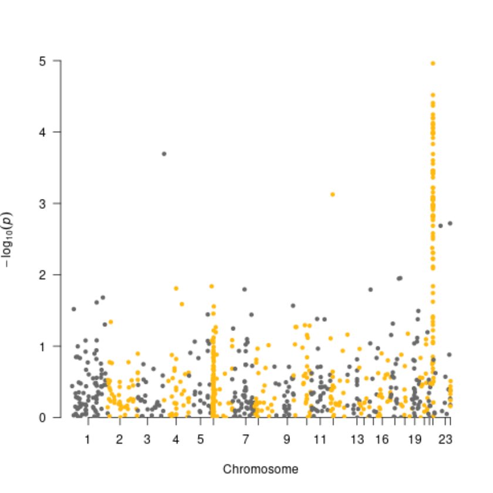

```python
# R codes- run in R Console
img <- readPNG("Manhattan_Plot_for_z-4-oh-Tam.png")
grid::grid.raster(img)
```

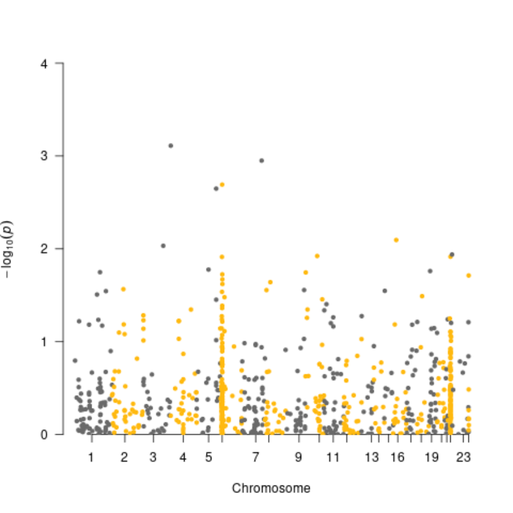

```python
# R codes- run in R Console
img <- readPNG("Manhattan_Plot_for_tamoxifen.png")
grid::grid.raster(img)
```

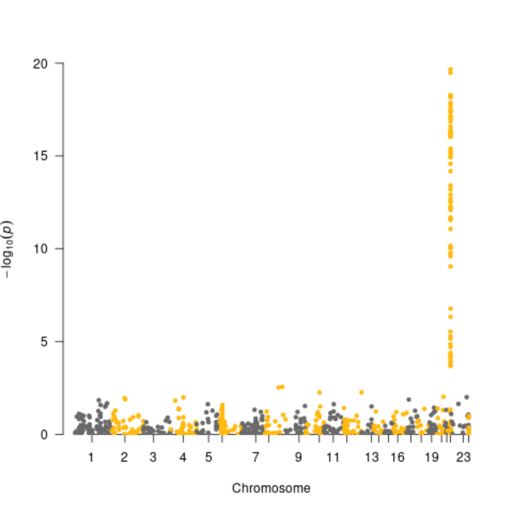

```python
# R codes- run in R Console
img <- readPNG("Manhattan_Plot_for_z-endoxifen_ratio.png")
grid::grid.raster(img)
```

## Generate Q-Q plot

A Quantile-Quantile (QQ) plot (in general) plots the observed quantiles of one distribution versus another OR plots the observed quantiles of a distribution versus the quantiles of the ideal distribution (in this case is normal distritbution). In GWAS we use a QQ plot to plot the quantile distribution of observed p-values (on the y-axis) versus the quantile distribution of expected p-values.

In an ideal GWAS case where there are **NO** causal polymorphisms, your QQ plot will be a straight line with a slope. However, in an ideal GWAS case where there **ARE** causal polymorphisms, your QQ plot will be **a line with a tail!**

The codes below generate the QQ plot with `qq` function in `qqman` package.

```python
# R codes- run in R Console
traits=c("z-4-oh-Tam","tamoxifen","z-endoxifen_ratio") #name of four traits

# trait 1: Z-4-OH-TAM
i=1
png(filename=paste0("Q-Q_Plot_for_", traits[i], ".png"), type="cairo")
qq(qassoc1$P)
dev.off()

# trait 2: tamoxifen
i=2
png(filename=paste0("Q-Q_Plot_for_", traits[i], ".png"), type="cairo")
qq(qassoc2$P)
dev.off()

# trait 3: z-endoxifen ratio
i=3
png(filename=paste0("Q-Q_Plot_for_", traits[i], ".png"), type="cairo")
qq(qassoc3$P)
dev.off()
```

**png:** 2

**png:** 2

**png:** 2

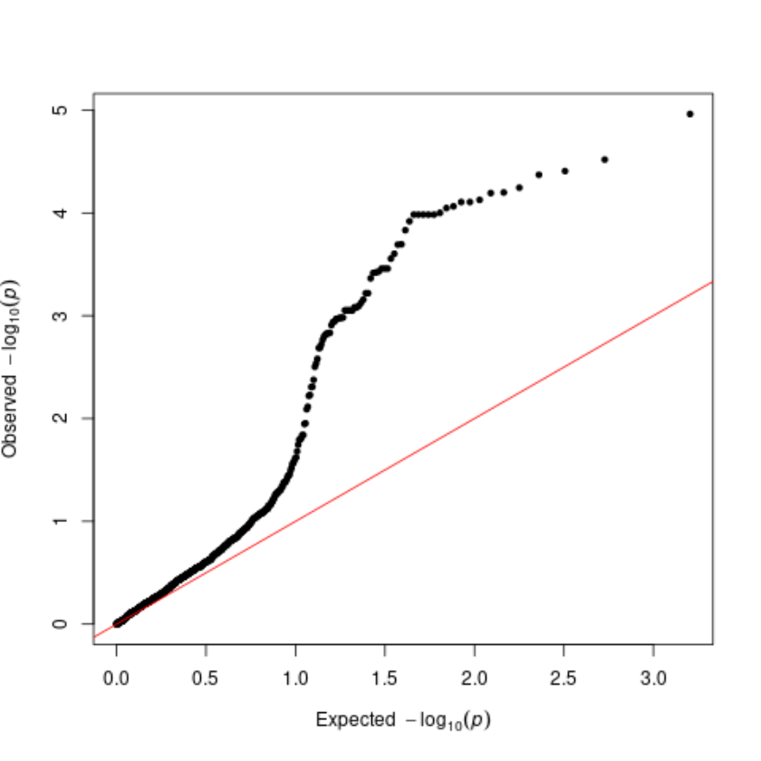

```python
# R codes- run in R Console
img1 <- readPNG("Q-Q_Plot_for_z-4-oh-Tam.png")
grid::grid.raster(img1)
```

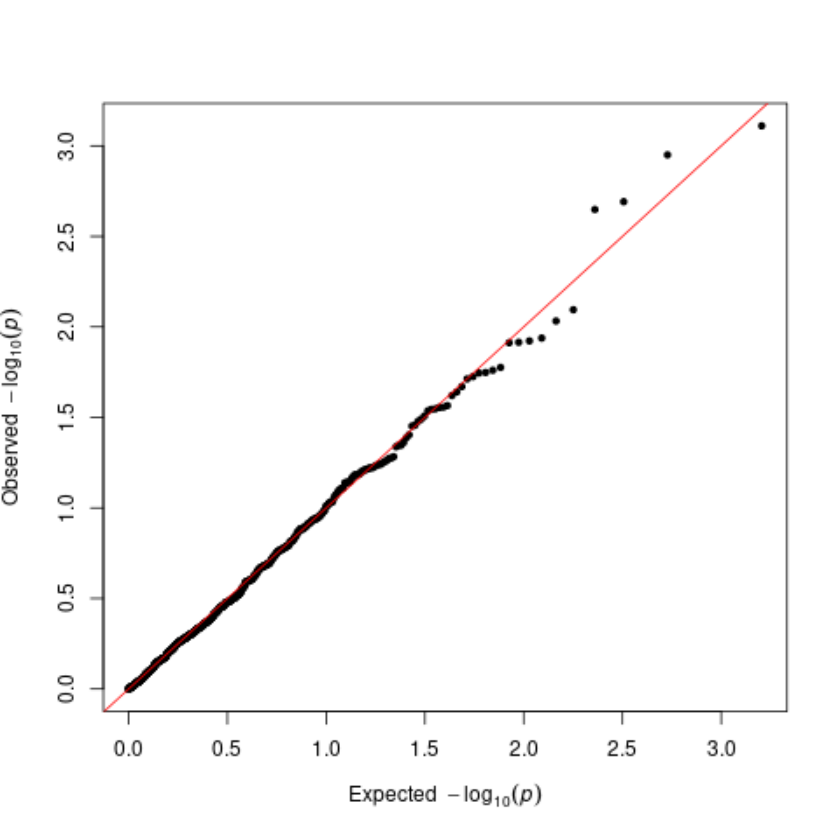

```python
# R codes- run in R Console
img2 <- readPNG("Q-Q_Plot_for_tamoxifen.png")
grid::grid.raster(img2)
```

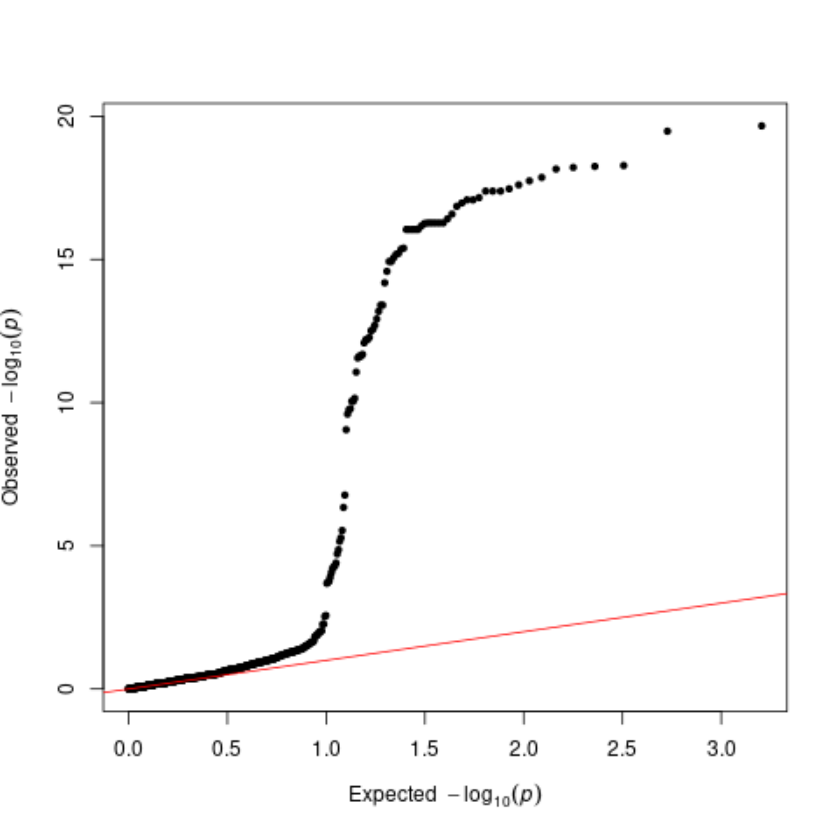

```python
# R codes- run in R Console
img3 <- readPNG("Q-Q_Plot_for_z-endoxifen_ratio.png")
grid::grid.raster(img3)
```

# Multiple-Test Correction

In the Association test, we simultanously performed tests on each SNP, which means we performed millions of test at the same time. Therefore, it is necessary that we carry out a multiple test correction procedure that control the overall type-I error rate using false discovery rate (FDR). Pleas refer to [this page](https://en.wikipedia.org/wiki/Multiple_comparisons_problem#:~:text=Multiple%20testing%20correction%20refers%20to,be%20more%20stringent%20than%20%CE%B1.) for multiple-test correction.

## Prepare R input files (in Linux)

```python
# bash codes- run in terminal
# Windows user need to run in Powershell App
awk '{print $1,$2,$3,$9}' younameit.P1.qassoc.adjusted > P1.qassoc.adjusted
awk '{print $1,$2,$3,$9}' younameit.P2.qassoc.adjusted > P2.qassoc.adjusted
awk '{print $1,$2,$3,$9}' younameit.P3.qassoc.adjusted > P3.qassoc.adjusted
```

## Significant SNPs after a multiple-test correction of FDR (using R)

The following code identifies the significant SNPs with the adjusted pvalues and a cutoff 0.05. SNPs with adjusted p-values < 0.05 are significant SNPs associated with the corresponding trait. The resulted significant SNP lists are save as "significant_SNPs*for*(trait).txt".

```python
# R codes- run in R Console
traits=c("z-4-oh-Tam","tamoxifen","z-endoxifen_ratio")
traits=as.matrix(traits)

for (i in 1:3){
  qassoc.adjusted=read.table(paste0("P", i, ".qassoc.adjusted"), header=T) #load association results
  sigidx=which(qassoc.adjusted$FDR_BH<0.05) #index of significant SNPs (FDR_BH<0.05)
  sigSNP=qassoc.adjusted[sigidx,] #extract association results for significant SNPs
  write.table(sigSNP, paste0("significant_SNPs_for_", traits[i],".txt"), row.names=F, col.names=T, quote=F, sep=" ") #save results
}
```

As a result, if you open the result files of each trait, you can observe that only "Z-endoxifen ratio" still have significant SNPs after multiple correction. Let's read in the results and match it with SNP annotation, so it can be used for plotting in next step.

```python
# R codes- run in R Console
library(data.table)
map<- fread("genotype_1k.map",header=F)
names(map) <- c("CHR","SNP","GP","BP") # assign header
zr_result <- fread("significant_SNPs_for_z-endoxifen_ratio.txt")
idx <- match(zr_result$SNP, map$SNP)#index of map that match with SNP in result
zr_result$BP <- map$BP[idx]
head(zr_result)
dim(zr_result) #get number of significant SNPs
```

A data.table: 6 × 5

| CHR <int> | SNP <chr> | UNADJ <dbl> | FDR_BH <dbl> | BP <int> |
| --- | --- | --- | --- | --- |
| 22 | kgp10581167 | 2.153e-20 | 1.335e-17 | 42397026 |
| 22 | rs8138080 | 3.318e-20 | 1.335e-17 | 42396371 |
| 22 | kgp12372278 | 5.256e-19 | 9.347e-17 | 42573139 |
| 22 | rs1062753 | 5.643e-19 | 9.347e-17 | 42392811 |
| 22 | kgp5009187 | 6.121e-19 | 9.347e-17 | 42580933 |
| 22 | kgp276463 | 6.967e-19 | 9.347e-17 | 42517922 |

1. 82

2. 5

There are a total of 82 significant SNPs after multiple adjusting. However,many SNP IDs are started with kgpXXXX. This kgp identifier is created by Illumina and there is no direct mapping from kpg identifier to rs identifier. I used a GitHub tutorial [here](https://github.com/nhettige/Updating-kgp-IDs-to-rs-IDs-for-SNPs-on-Illumina-HumanOmni2.5M-array) to match the kgp identifier with rs identifier based on SNP position. This mapping is done using the [UCSC Table Browser GRCh38](http://genome.ucsc.edu/cgi-bin/hgTables).

The codes below extract the SNPs with kgp identifier using `grepl` function, and modified the table into UCSC required format. The resulted SNP list is saved in `kgp_snps.txt`.

```python
# R codes- run in R Console
kgp_snps <- zr_result[grepl("kgp",zr_result$SNP),]
head(kgp_snps)
kgp_snps$CHR<- paste0("chr",kgp_snps$CHR)
kgp_snps$BP_1<- kgp_snps$BP-1
fwrite(kgp_snps[,c("CHR","BP_1","BP","SNP")], "kgp_snps.txt", sep=" ", quote=F, row.name=F, col.name=F)
dim(kgp_snps)
```

A data.table: 6 × 5

| CHR <int> | SNP <chr> | UNADJ <dbl> | FDR_BH <dbl> | BP <int> |
| --- | --- | --- | --- | --- |
| 22 | kgp10581167 | 2.153e-20 | 1.335e-17 | 42397026 |
| 22 | kgp12372278 | 5.256e-19 | 9.347e-17 | 42573139 |
| 22 | kgp5009187 | 6.121e-19 | 9.347e-17 | 42580933 |
| 22 | kgp276463 | 6.967e-19 | 9.347e-17 | 42517922 |
| 22 | kgp5109906 | 1.799e-18 | 1.810e-16 | 42567451 |
| 22 | kgp7814563 | 2.489e-18 | 2.226e-16 | 42465788 |

1. 53

2. 6

```python
# R codes- run in R Console
kgp_rs<- fread("kgp_rs.txt",header=F)
names(kgp_rs)<- c("CHR","BP_1","BP","SNP")# assign header
idx <- match(kgp_rs$BP, kgp_snps$BP)# get index of these matched SNPs in results
kgp_match<- kgp_snps[idx[!is.na(idx)],]
kgp_match$SNP<- kgp_rs$SNP[!is.na(idx)] # replace kgp identifier with rs identifier
kgp_match
```

A data.table: 2 × 6

| CHR <chr> | SNP <chr> | UNADJ <dbl> | FDR_BH <dbl> | BP <int> | BP_1 <dbl> |
| --- | --- | --- | --- | --- | --- |
| chr22 | rs60133761 | 5.314e-17 | 1.711e-15 | 42668504 | 42668503 |
| chr22 | rs140061401 | 9.004e-17 | 2.265e-15 | 42395960 | 42395959 |

Then, these 2 match SNPs are combined with rs SNPs in the results. Print the results and look at the dimension.

```python
# R codes- run in R Console
rs_snps <- zr_result[grepl("rs",zr_result$SNP),]
kgp_match$CHR <- "22"
rs_snps <- rbind(rs_snps, kgp_match[,-6])
fwrite(rs_snps, "significant_snps_with_rs_for_z-endoxifen-ratio.txt", sep=" ", quote=F, row.name=F, col.name=T)
dim(rs_snps)
rs_snps
```

1. 31

2. 5

A data.table: 31 × 5

| CHR <chr> | SNP <chr> | UNADJ <dbl> | FDR_BH <dbl> | BP <int> |
| --- | --- | --- | --- | --- |
| 22 | rs8138080 | 3.318e-20 | 1.335e-17 | 42396371 |
| 22 | rs1062753 | 5.643e-19 | 9.347e-17 | 42392811 |
| 22 | rs4467371 | 1.365e-18 | 1.570e-16 | 42541328 |
| 22 | rs7245 | 4.102e-18 | 2.540e-16 | 42481849 |
| 22 | rs2284087 | 4.102e-18 | 2.540e-16 | 42485671 |
| 22 | rs5758589 | 4.102e-18 | 2.540e-16 | 42518382 |
| 22 | rs5751247 | 6.923e-18 | 3.981e-16 | 42633054 |
| 22 | rs2011944 | 8.301e-18 | 4.176e-16 | 42569999 |
| 22 | rs4453786 | 1.068e-17 | 5.059e-16 | 42563308 |
| 22 | rs5751221 | 3.812e-17 | 1.534e-15 | 42516366 |
| 22 | rs5758651 | 5.314e-17 | 1.711e-15 | 42609148 |
| 22 | rs133335 | 5.540e-17 | 1.715e-15 | 42416056 |
| 22 | rs1063392 | 9.004e-17 | 2.265e-15 | 42454950 |
| 22 | rs932376 | 4.397e-16 | 1.041e-14 | 42614362 |
| 22 | rs8140869 | 1.996e-13 | 3.492e-12 | 42344297 |
| 22 | rs5751191 | 2.773e-13 | 4.749e-12 | 42370991 |
| 22 | rs5751255 | 5.269e-13 | 8.656e-12 | 42648408 |
| 22 | rs5751239 | 2.071e-12 | 3.146e-11 | 42592239 |
| 22 | rs5758511 | 2.764e-12 | 3.974e-11 | 42336172 |
| 22 | rs1052717 | 7.077e-11 | 9.822e-10 | 42281429 |
| 22 | rs133280 | 8.991e-11 | 1.206e-09 | 42255525 |
| 22 | rs134871 | 1.635e-10 | 2.157e-09 | 42652716 |
| 22 | rs742086 | 1.773e-10 | 2.302e-09 | 42552253 |
| 22 | rs6002673 | 1.695e-07 | 2.100e-06 | 42691296 |
| 22 | rs7285782 | 7.006e-06 | 8.173e-05 | 42225018 |
| 22 | rs17365991 | 1.373e-05 | 1.579e-04 | 41790179 |
| 22 | rs9607821 | 5.431e-05 | 5.908e-04 | 41983938 |
| 8 | rs1487173 | 2.726e-03 | 2.709e-02 | 122405332 |
| 8 | rs1042381 | 2.954e-03 | 2.900e-02 | 97614661 |
| 22 | rs60133761 | 5.314e-17 | 1.711e-15 | 42668504 |
| 22 | rs140061401 | 9.004e-17 | 2.265e-15 | 42395960 |

# Regional Association Plot

## Regional association plot

`make.fancy.locus.plot` is an R function for highlighting the statistical strength of an association in the context of the association results for surrounding markers, gene annotations, estimated recombination rates and pairwise correlations between the surrounding markers and the putative associated variant, see the reference page http://www.broadinstitute.org/diabetes/scandinavs/figures.html

You need provide a file that contains the following data for every SNP across the region of interest: position, p-value, a label to indicate whether a SNP is “typed" or "imputed", and the r-squared between that SNP and the putative associated variant.

All SNPs in this file will be plotted with their corresponding P-values (as -log10 values) as a function of chromosomal position. SNPs that are "typed" are plotted as diamonds; "imputed" SNPs are plotted as circles. Estimated recombination rates are plotted to reflect the local LD structure around the associated SNP and their correlated proxies (bright red indicating highly correlated, faint red indicating weakly correlated).

## Obtain regional SNPs (using R)

As most of the significant SNPs are located within chromosome 22, we could take a closer look at this specific chromosome.

```python
# R codes- run in R Console
qassoc=read.table("younameit.P3.qassoc", header=T, stringsAsFactors=F) #load association results
idx=which(qassoc$CHR==22 & qassoc$BP>=4200000 & qassoc$BP<=52000000 & qassoc$SNP!="---" & !is.na(qassoc$P)) #index of regional SNPs
TYPE=rep("typed", length(idx)) #all SNPs are typed SNPs
region=data.frame(qassoc$SNP[idx], qassoc$BP[idx], qassoc$P[idx], TYPE, qassoc$R2[idx]) #information for regional SNPs
write.table(region, "regional_SNPs.txt", row.names=F, col.names=c("SNP", "POS", "PVAL", "TYPE", "RSQR"), quote=F, sep=" ")
head(region)
```

A data.frame: 6 × 5

|  | qassoc.SNP.idx. <chr> | qassoc.BP.idx. <int> | qassoc.P.idx. <dbl> | TYPE <chr> | qassoc.R2.idx. <dbl> |
| --- | --- | --- | --- | --- | --- |
| 1 | rs12166151 | 24479193 | 6.178e-01 | typed | 1.313e-03 |
| 2 | rs229526 | 37581422 | 9.326e-01 | typed | 3.793e-05 |
| 3 | rs6572 | 37621445 | 2.994e-01 | typed | 5.696e-03 |
| 4 | rs2239774 | 37637653 | 5.653e-02 | typed | 1.921e-02 |
| 5 | kgp11471870 | 41547154 | 2.899e-06 | typed | 1.091e-01 |
| 6 | kgp3940114 | 41627386 | 6.354e-05 | typed | 8.094e-02 |

## Create regional association plot (using R)

The regional association plot is generated by `make.fancy.locus.plot`. The arguments in this function is:

**The following codes might generate several warning messages and you can safely ignore them.**

The souce code "**regional_association_plot.r**", the estimated recombination rate from HapMap and the gene annotations from the UCSC genome browser (using Build 35 coordinates) should be available in the same folder.

```python
# R codes- run in R Console
source("regional_association_plot.r") #load source function
locus=read.table("regional_SNPs.txt", header=T, row.names=1) #read information of regional SNPs
png("assocplot_rs8138080.png")
make.fancy.locus.plot("rs8138080", "rs8138080", "22", locus, 25, 1.709e-15)
#specify which SNP is the key association ("rs8138080"),
# provide a header title ("rs8138080"),
# specify which chromosome it is ("22"),
# provide the locus of the SNP,
# specify the range of p-value,
# provide the replication or joint p-value (4.335e-14)
dev.off()
```

[output not shown]

[output cut: 230 more lines]

[output not shown]

**png:** 2

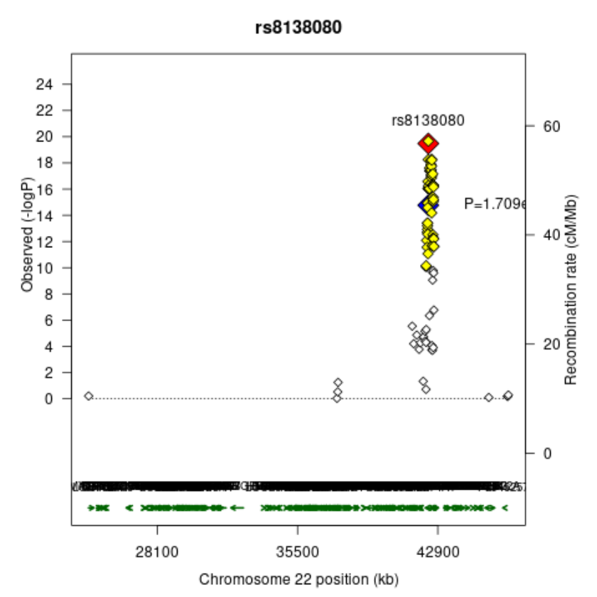

```python
# R codes- run in R Console
img_fancy <- readPNG("assocplot_rs8138080.png")
grid::grid.raster(img_fancy)
```

There are definitely a lot more ways to generate a regional association plot. We can use the `manhattan` function in the `qqman` package by input a subset of the results. `QCGWAS` package also has a `plot_regional` function where you can specify the chromosome or zoom-in region. If you are familiar with R, you can also write your own functions with ggplot or base plot to enable more flexibility in customizing the plots. Below is an example for the `plot_regional` function.

We need to combine the SNP information and test results in P3.assoc and P3.assoc.adjusted. We use the `match` function to match the SNP ID in these two files.

```python
# R codes- run in R Console
# read in, the SNP doesn't match
qassoc=fread(paste0("P3.qassoc"), header=T)
qassoc.adjusted=fread("P3.qassoc.adjusted", header=T)
head(qassoc.adjusted)
head(qassoc)
```

A data.table: 6 × 4

| CHR <int> | SNP <chr> | UNADJ <dbl> | FDR_BH <dbl> |
| --- | --- | --- | --- |
| 22 | kgp10581167 | 2.153e-20 | 1.335e-17 |
| 22 | rs8138080 | 3.318e-20 | 1.335e-17 |
| 22 | kgp12372278 | 5.256e-19 | 9.347e-17 |
| 22 | rs1062753 | 5.643e-19 | 9.347e-17 |
| 22 | kgp5009187 | 6.121e-19 | 9.347e-17 |
| 22 | kgp276463 | 6.967e-19 | 9.347e-17 |

A data.table: 6 × 4

| CHR <int> | SNP <chr> | BP <int> | P <dbl> |
| --- | --- | --- | --- |
| 0 | rs2698846 | 0 | NA |
| 0 | rs2542903 | 0 | NA |
| 0 | rs1059667 | 0 | NA |
| 0 | rs35144699 | 0 | 0.5454 |
| 0 | rs35425675 | 0 | 0.5770 |
| 0 | rs3876241 | 0 | NA |

```python
# R codes- run in R Console
# match and merge data
qassoc<-qassoc[!is.na(qassoc$P),]
idx<-match(qassoc.adjusted$SNP,qassoc$SNP)
qassoc_sub<- qassoc[idx,]
qassoc.adjusted$BP<-qassoc_sub$BP
qassoc.adjusted$P<-qassoc_sub$P
```

Next, we are able to call the `plot_regional` function to generate regional plot for our specified chromosome number and region. This function uses the base plot function in R instead of ggplot. The `col` option enables a conditional coloring by highlighting the significant SNPs as yellow. Finally, the function directly saves the figure to PNG under current directory in "regional_association_plot.png". You can specify the cutoff value for the SNPs you want to label in the plot with `name_cutoff_p`. By default, this option is NULL and there is no label.

```python
# R codes- run in R Console
# generate plot
colnames(qassoc.adjusted)<-c("CHR","MARKER","PVALUE","FDR_BH","POSITION","P2")
# label the most significant SNP
# color all significant SNPs
plot_regional(qassoc.adjusted, chr=22, start_pos=41000000,end_pos=51000000,
              name_cutoff_p=min(qassoc.adjusted$PVALUE),
             col=ifelse( qassoc.adjusted$FDR_BH<=0.05 , "darkgoldenrod1","dimgray"))
#plot_regional(qassoc.region, chr=22, start_pos=41000000,end_pos=51000000,name_cutoff_p=NULL) #no label
```

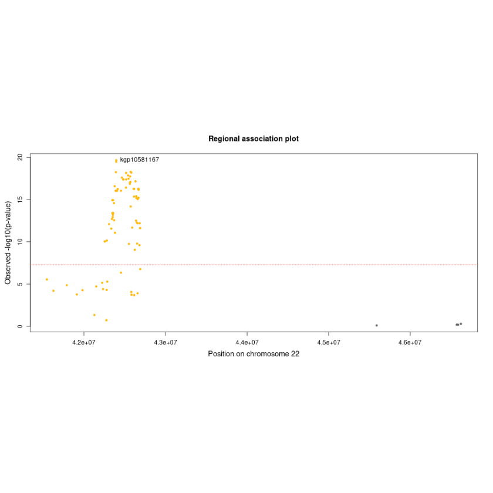

```python
# R codes- run in R Console
regional_plot <- readPNG("regional_association_plot.png")
grid::grid.raster(regional_plot)
```

# Distribution of Z-endoxifen ratio for rs8138080

After an overview of the regional association plot, it might also be intersting to look at the distribution of phenotype on a specific SNP. Here, we pick the most significant SNP `rs8138080` as an example.

## Obtain phenotype data (Z-endoxifen ratio) (using R)

The imputed phenotype is in file `phenotype0.txt`.

```python
# R codes- run in R Console
pheno=read.table("phenotype0.txt") #read phenotype data
zr=pheno[,3] #obtain phenotype data of Z-endoxifen ratio (Col 3)
write.table(zr,"z_endoxifen_ratio.txt",row.names=F,col.names=F,quote=F,sep=" ") #save phenotype data of Z-endoxifen ratio
```

## Obtain genotype for significant SNPs (using R)

The following code finds index for the significant SNPs rs8138080 in the genotype.map file and then extract the genotype from the genotype.ped file. Note that the number of columns in PED file doesn't match that in MAP file. PED file has 6 column of family information in front, and there are 2 allels for each SNP.

```python
# R codes- run in R Console
# index of significant SNPs in PED file (using R)
map=fread("genotype_1k.map",header=F) #read MAP file
names(map)=c("CHR", "SNP", "GP", "BP") #specify names of MAP file
index=which(map$SNP %in% "rs8138080") #index of rs8138080 in MAP file
genoidx=sort(c(2*index+5, 2*index+6)) #index of rs8138080 in PED file
genoidx
# 1901 1902 # this is the genotype position for rs8138080 in PED file
```

1. 1901

2. 1902

```python
# bash codes- run in terminal
# Windows user need to run in Powershell App
# extract genotype for rs8138080
awk '{print $1901 $1902}' < genotype_1k.ped > rs8138080.txt
```

## Create Box plot (using R)

The follwing code generate the box plot for the phenotype `z-endoxifen ratio` by the genotypes of SNP rs8138080.

```
geno
00 AA AG GG
 1 20 85 86
```

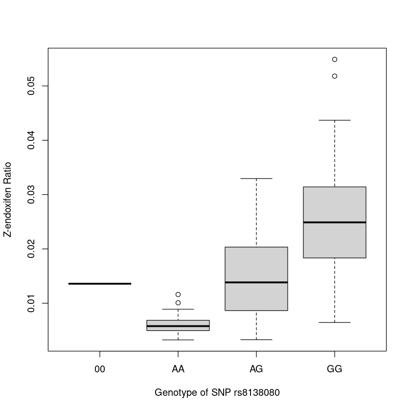

```python
# R codes- run in R Console
pheno=read.table("z_endoxifen_ratio.txt") #read phenotype data of Z-endoxifen ratio
geno=read.table("rs8138080.txt", sep="\t") #read genotype data of rs8138080
pheno=as.matrix(pheno) #create a matrix from the phenotype data
geno=as.matrix(geno) #create a matrix from the genotype data
table(geno) #number of individuals having AA, AG and GG
boxplot(pheno~geno, xlab="Genotype of SNP rs8138080", ylab="Z-endoxifen Ratio") #create Box Plot
```

# Proportion of Variation Explained by rs8138080

Marginal $R^2$ reveals the coefficient of determination of a full regression model that contains one or more SNPs. Here we calculate the the marginal $R^2$ to assess proportion of variation that can be explained by SNP rs8138080.

## Recode genotype of significant SNPs (using R)

We wll first recode the genotype into numbers:

- AA as "0"
- AG as "1"
- GG as "2"

```python
# R codes- run in R Console
geno=read.table("rs8138080.txt") #read genotype data of rs8138080
geno=as.matrix(geno) #create a matrix from the genotype data
geno[geno=="GG"]=2 #replace GG with 2
geno[geno=="AG"|geno=="GA"]=1 #replace AG and GA with 1
geno[geno=="AA"]=0 #replace AA with 0
write.table(geno, "rs8138080_geno.txt", row.names=F, col.names=F, quote=F, sep=" ") #save recoded genotype data
```

## Calculate marginal $R^2$ (using R)

The $R^2$ value is included in the linear regression results.

```python
# R codes- run in R Console
pheno=read.table("z_endoxifen_ratio.txt") #read phenotype data
geno=read.table("rs8138080_geno.txt") #read genotype data of rs8138080
pheno=as.matrix(pheno) #create a matrix from the phenotype data
geno=as.matrix(geno) #create a matrix from the genotype data
fit=lm(pheno~geno) #fit a linear regression of phenotype against genotype
summary(fit)$r.squared #R squared of the regression
```

0.358223494904956

The $R^2$ is 0.358 in this case, meaning that about 35.8% of variation is explained by rs8138080.

# PRACTICE TIME

## Practice 1

**Calculate the marginal $R^2$ for other significant SNPs, how large is it compared with the most significant SNP `rs8138080`?**

```python
# R codes- run in R Console
# write your code here
```

## Practice 2

**Instructions**: The codes to read in genotype for all 5 SNPs is already provided. `geno` is a combined genotype data with 5 columns, with each represents a SNP. Repeat the last two lines in section 11.2 to calculate the $R^2$.

```python
# R codes- run in R Console
# here is the code to read in phenotype and combine genotype data for all 5 SNPs
pheno=read.table("z_endoxifen_ratio.txt") #read phenotype data
geno1=read.table("rs8138080_geno.txt") #read genotype data of rs8138080
geno2=read.table("rs4467371_geno.txt")
geno3=read.table("rs2011944_geno.txt")
geno4=read.table("rs1062753_geno.txt")
geno5=read.table("rs4453786_geno.txt")
geno=cbind(geno1, geno2, geno3, geno4, geno5)
pheno=as.matrix(pheno) #create a matrix from the phenotype data
geno=as.matrix(geno) #create a matrix from the genotype data
```

```python
# R codes- run in R Console
## write your code here to fit linear regression and calculate R^2
```